# Calibrating Jomon Ceramic Chronology into Calendar Dates

E.Crema

## Introduction

This is a short tutorial for using the posterior samples and the methodology presented in [Crema and Kobyashi 2020](https://doi.org/10.1016/j.jas.2020.105136) to estimate the absolute calendar dates of Jomon ceramic phases.

## Setup

In order calibrate ceramic phases you will need R statistical computing language installed in your machine and have the following three files in your working directory: posteriorSamples.RData, [utilities.R](https://github.com/ercrema/jomonPhasesAndPopulation/raw/master/R/mcsim.R), and mcsim.R.

```r
source('mcsim.R')
load('posteriorSamples.RData')
```

Or alternativately you can download and load the R image containing the posteriors and `mcsim()` function directly using the following command:

```r
#source('https://github.com/ercrema/jomonPhasesAndPopulation/raw/master/R/utilities.R')
#source('https://github.com/ercrema/jomonPhasesAndPopulation/raw/master/R/mcsim.R')
#load(file = url('https://github.com/ercrema/jomonPhasesAndPopulation/raw/master/R_images/posteriorSamples.RData'))
source('https://github.com/ercrema/jomonPhasesAndPopulation/raw/intcal20version/R/mcsim.R')
source('https://github.com/ercrema/jomonPhasesAndPopulation/raw/intcal20version/R/utilities.R')
load(file = url('https://github.com/ercrema/jomonPhasesAndPopulation/raw/intcal20version/R_images/posteriorSamples.RData'))
```

## Data Preparation

The main argument for the `mcsim()` is a data.frame where each row contains an object to be dated with two columns (with names `$StartPhase` and `$EndPhase`) containing the start and the end Jomon ceramic phases for the timespan of possible existence of each event to be dated. The name of the ceramic phases should follow the convention used in Table 1 of [Crema and Kobyashi 2020](https://doi.org/10.1016/j.jas.2020.105136) reported in a redacted form below:

| **Period** | **Ceramic Phase Name** | **Kobayashi 2017** | **Ceramic Phase in Suzuki’s Pithouse Data** |  |  |  |
| --- | --- | --- | --- | --- | --- | --- |
| End of Upper Palaeolithic | S0 | S0 | Mumon doki |  |  |  |
| Incipient Jomon | S1.1 | S1-1 | Ryūkisenmon-kei |  |  |  |
|  | S1.2 | S1-2 | Biryūkisenmon-kei; Tsumegatamon-kei |  |  |  |
|  | S2.1 | S2-1 | Tsumegatamon-kei; Ōnatsumon-kei |  |  |  |
|  | S2.2 | S2-2 | Tajōmon-kei |  |  |  |
| Initial Jomon | S3 | S3-1 | Igusa I; Igusa II; Daimaru; Natsushima; Inaridai; Tateno; Inarihara; Ōurayama; Hanawadai 1; Hanawadai 2; Hirasaka; |  |  |  |
|  |  | S3-2 |  |  |  |  |
|  |  | S3-3 |  |  |  |  |
|  |  | S3-4 |  |  |  |  |
|  | S4 | S4 |  | Mito; Lower Tado; Upper Tado; Hosokubo |  |  |
|  | S5 | S5 |  | Shiboguchi; Nojima |  |  |
|  | S6 | S6 |  | Ugajimadai |  |  |
|  | S7 | S7 | Lower Kayama; Upper Kayama |  |  |  |
|  | S8 | S8 | Uenoyama; Irumi I; Irumi II ; Ishiyama; Okkōshi; Tenjinyama; Kaminokidai; Shioya; Shimoyoshii |  |  |  |
| Early Jomon | Z1 | Z1 | Lower Hanazumi |  |  |  |
|  | Z2 | Z2 | Sekiyama; Futatsuki; Kaminoki |  |  |  |
|  | Z3 | Z3 | Kurohama; Ario |  |  |  |
|  | Z4 | Z4 | Moroiso a; Minamiōhara |  |  |  |
|  | Z5 | Z5 | Moroiso b; Uehara |  |  |  |
|  | Z6 | Z6 | Moroiso c; Hinata I; Kagobatake I; Shitajima |  |  |  |
|  | Z7 | Z7 | Jūsanbodai; Hinata II; Kagohata II |  |  |  |
| Middle Jomon | C1 | C1 | Goryōgadai 1 |  |  |  |
|  | C234 | C2~C4 | Goryōgadai 2 |  |  |  |
|  | C56 | C5 | Atamadai 1a; Atamadai 1b; Mujinasawa; Katsuzaka I; Aramichi |  |  |  |
|  |  | C6 |  |  |  |  |
|  | C78 | C7 |  | Atamadai 2; Atamadai 3; Katsuzaka 2; Tōnai I; Tōnai II; |  |  |
|  |  | C8 |  |  |  |  |
|  | C9 | C9a | Idojiri I;Idojiri III; Katsuzaka 3; Atamadai 4 |  |  |  |
|  |  | C9bc |  |  |  |  |
|  | C10 | C10a |  |  | Daigi 8a; Kasori E1 (EI)* Sori I |  |
|  |  | C10b |  |  |  |  |
|  |  | C10c |  |  |  |  |
|  | C11 | C11ab | Daigi 8b; Kasori E2 (EI)*; Sori II; Sori III |  |  |  |
|  |  | C11c |  |  |  |  |
|  | C12 | C12a |  | Daigi 9; Kasori E3 (EII-EIII)*; Sori IV;SoriV |  |  |
|  |  | C12b |  |  |  |  |
|  |  | C12c |  |  |  |  |
|  | C13 | C13 | Kasori E4 (EIV)*; Daigi 10; |  |  |  |
|  | C14 | - | Kasori EV; Daigi 10; |  |  |  |
| Late Jomon | K1 | K1-1 | Shōmyōji 1;Shōmyōji 2 |  |  |  |
|  |  | K1-2 |  |  |  |  |
|  |  | K1-3 |  |  |  |  |
|  | K2 | K2 |  |  |  | Horinouchi 1 |
|  | K3 | K3 |  |  |  | Horinouchi 2 |
|  | K4 | K4 | Kasori B1 |  |  |  |
|  | K5 | K5 | Kasori B2 |  |  |  |
|  | K6 | K6 | Kasori B3 |  |  |  |
|  | K7 | K7 | Takaihigashi; Sōya |  |  |  |
|  | K8 | K8 | Angyō 1; Angyō 2 |  |  |  |
| Final Jomon | B1 | B1 | Ōbora B; Angyō 3a |  |  |  |
|  | B2 | B2 | Ōbora BC; Angyō 3b |  |  |  |
|  | B3 | B3 | Ōbora C1; Angyō 3c; Maeura 1 |  |  |  |
|  | B4 | B4 | Ōbora C2; Angyō 3d; Maeura 2 |  |  |  |
|  | B5 | B5 | Ōbora A; Chiami; Kōri I |  |  |  |
|  | B6 | B6 | Ōbora A’; Arami; Kōri II |  |  |  |

For example, suppose you have four pit-dwellings dated as follows:

- PithouseA; Daigi8a ~ Daigi8b
- PithouseB; Horinouchi ~ Kasori B
- PithouseC; Horinouchi ~ Kasori B
- PithouseD; Moroiso a

The intput data.frame would be constructed as follows:

```r
StartPhase = c('C10','K2','K2','Z4')
EndPhase = c('C11','K6','K6','Z4')
df = data.frame(StartPhase=StartPhase,EndPhase=EndPhase)
rownames(df) = c('A','B','C','D') #this is not strictly necessary
print(df)
```

```
##   StartPhase EndPhase
## A        C10      C11
## B         K2       K6
## C         K2       K6
## D         Z4       Z4
```

Notice that there are as many rows as the number of entities to be dated (i.e. chronologically identical iterms should be repeated) and that entities with no *Phase assignment uncertainty* (i.e. assigned to a single phase) would have identical entries for the `$StartPhase` and `$EndPhase` fields.

## Using the mcsim() function

The `mcsim()` function randomly generates user-defined number (argument `nsim`) of calendar dates taking into account *phase assignment uncertainty*, *within-phase uncertainty*, and *phase boundary uncertainty*. The *within-phase uncertainty* and *phase boundary uncertainty* are modelled by providing pre-processed posterior samples contained the image file `posteriorSamples.RData`. These includes trapezoid (`postTrapezoid`), Gaussian (`postGaussian`), and uniform (`postUniform`) distributions. *Phase assignment uncertainty* is controlled by the argument `weights` and could be one between `equal` (for equal probability assigned to each possible phase in the interval), `variance` (for probabilities proportional to the duration of possibles phases in the interval), and `custom` (for user defined probabilities). For example, the following generates 1000 calendar dates using the Trapezoid distribution and a duration based modelling of *phase assignment uncertainty*:

```r
res=mcsim(df,nsim=1000,posterior=postTrapezoid,weights="variance",verbose=FALSE)
```

The resulting object is a matrix with each row corresponding to each event. Thus the estimated age of pithouse A would be:

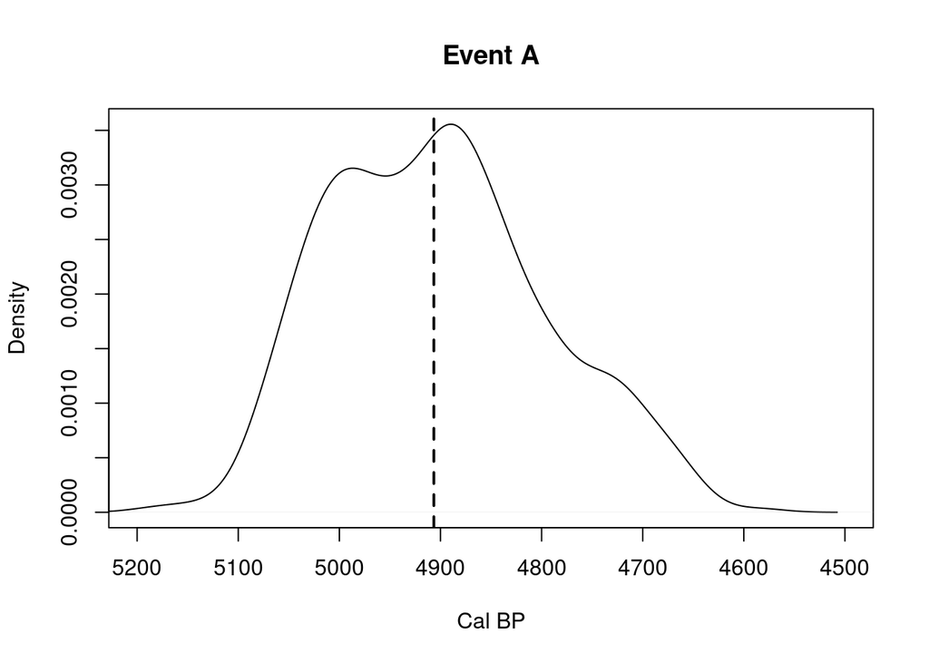

```r
eventA = res[1,]
plot(density(eventA),xlim=c(5200,4500),xlab='Cal BP',main='Event A')
abline(v=median(eventA),lwd=2,lty=2)
```

```r
quantile(eventA,prob=c(0.025,0.975)) #95% percentile interval
```

```
##     2.5%    97.5%
## 4680.887 5075.490
```

```r
w = vector('list',length=4)
w[[1]] = c(0.3,0.7)
w[[2]] = c(0.2,0.3,0.2,0.2,0.1)
w[[3]] = c(0.1,0.3,0.3,0.2,0.1)
w[[4]] = c(1)

res=mcsim(df,nsim=1000,posterior=postTrapezoid,weights="variance",weightList = w,verbose=FALSE)
```

It is also possible to provide for each element of `weightList` a matrix instead of vector, with the number of columns corresponding to the number of phases within the timespan. The `mcsim()` function will randomly select a row from sum matrix for each iteration. This approach can, for example, be used when the *phase assignement uncertainty* is modelled based on the observed frequencies of events for each phase. The script below illustrates a workflow where the Dirichlet distribution is used as a conjugate prior of a multinomial distribution:

```r
### Function for generating sample probabilities from the dirichlet distribution ###
rdirichlet<-function (n, alpha)
{
  l <- length(alpha)
  x <- matrix(rgamma(l * n, alpha), ncol = l, byrow = TRUE)
  sm <- x %*% rep(1, l)
  x/as.vector(sm)
}


# Hypothetical Observed Frequencies of Events
Z4 = 10
C10 = 67
C11 = 23
K2 = 1
K3 = 2
K4 = 34
K5 = 67
K6 = 23

#
w2 = vector('list', length=4)
w2[[1]]=rdirichlet(n=1000,alpha=c(C10,C11))
w2[[2]] = w2[[3]]=rdirichlet(n=1000,alpha=c(K2,K3,K4,K5,K6))
w2[[4]] = c(1)

res=mcsim(df,nsim=1000,posterior=postTrapezoid,weights="custom",weightList = w2,verbose=FALSE)
```